# Regresión Lineal Simple y Múltiple

Ricardo Macías Bohórquez

21 de October de 2024

# Regresión Lineal Simple y Múltiple

En este documento, exploraremos cómo aplicar y analizar la **regresión lineal simple** y la **regresión lineal múltiple**. Estos modelos permiten predecir el valor de una variable dependiente en función de una o más variables independientes.

## 1. Conceptos Fundamentales

### 1.1 ¿Qué es la Regresión Lineal?

La **regresión lineal** es una técnica estadística utilizada para modelar la relación entre una variable dependiente (o respuesta) y una o más variables independientes (o explicativas). El objetivo es encontrar la **mejor línea** que describa cómo la variable dependiente cambia a medida que cambian las variables independientes.

### 1.2 Supuestos de la Regresión Lineal

1. **Linealidad**: Existe una relación lineal entre las variables dependientes e independientes.
2. **Independencia**: Las observaciones son independientes entre sí.
3. **Normalidad de los residuos**: Los residuos del modelo siguen una distribución normal.
4. **Homocedasticidad**: Los residuos presentan una varianza constante a lo largo de los valores predichos.

## 2. Regresión Lineal Simple

### 2.1 Explicación

La **regresión lineal simple** estudia la relación entre una variable dependiente y una sola variable independiente. El modelo tiene la siguiente forma:

$$Y = \beta_0 + \beta_1 X + \epsilon$$

### 2.2 Ejemplo: Regresión lineal entre `mpg` (Millas por Galón) y `wt` (Peso) en `mtcars`

#### 1. Cargar los datos

```r
# Cargar la base de datos mtcars
data(mtcars)

# Visualizar las primeras filas
head(mtcars)
```

```
##                    mpg cyl disp  hp drat    wt  qsec vs am gear carb
## Mazda RX4         21.0   6  160 110 3.90 2.620 16.46  0  1    4    4
## Mazda RX4 Wag     21.0   6  160 110 3.90 2.875 17.02  0  1    4    4
## Datsun 710        22.8   4  108  93 3.85 2.320 18.61  1  1    4    1
## Hornet 4 Drive    21.4   6  258 110 3.08 3.215 19.44  1  0    3    1
## Hornet Sportabout 18.7   8  360 175 3.15 3.440 17.02  0  0    3    2
## Valiant           18.1   6  225 105 2.76 3.460 20.22  1  0    3    1
```

#### 2. Visualizar la relación entre las variables

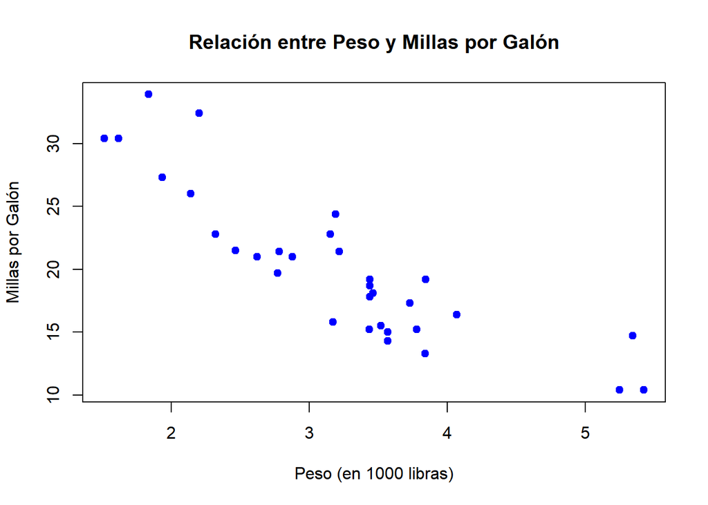

```r
# Gráfico de dispersión entre mpg y wt
plot(mtcars$wt, mtcars$mpg,
     main = "Relación entre Peso y Millas por Galón",
     xlab = "Peso (en 1000 libras)",
     ylab = "Millas por Galón",
     pch = 19, col = "blue")
```

#### 3. Ajustar el modelo de regresión lineal

```r
# Ajustar el modelo de regresión lineal
modelo_simple <- lm(mpg ~ wt, data = mtcars)

# Mostrar el resumen del modelo
summary(modelo_simple)
```

```
##
## Call:
## lm(formula = mpg ~ wt, data = mtcars)
##
## Residuals:
##     Min      1Q  Median      3Q     Max
## -4.5432 -2.3647 -0.1252  1.4096  6.8727
##
## Coefficients:
##             Estimate Std. Error t value Pr(>|t|)
## (Intercept)  37.2851     1.8776  19.858  < 2e-16 ***
## wt           -5.3445     0.5591  -9.559 1.29e-10 ***
## ---
## Signif. codes:  0 '***' 0.001 '**' 0.01 '*' 0.05 '.' 0.1 ' ' 1
##
## Residual standard error: 3.046 on 30 degrees of freedom
## Multiple R-squared:  0.7528, Adjusted R-squared:  0.7446
## F-statistic: 91.38 on 1 and 30 DF,  p-value: 1.294e-10
```

### 2.3 Interpretación de los resultados

- **Intercepto ($\beta_0$)**: Indica que cuando el peso (`wt`) es 0, el valor de `mpg` sería 37.29. Este valor es solo teórico, ya que no tendría sentido un automóvil con peso 0.
- **Pendiente ($\beta_1 = -5.34$)**: Esto significa que por cada 1000 libras adicionales de peso, el consumo de combustible (`mpg`) disminuye en 5.34 millas por galón.
- **p-value ($p < 0.05$)**: El valor p asociado a `wt` es extremadamente bajo (1.29e-10), lo que indica que el peso tiene un impacto significativo en `mpg`.
- **R-cuadrado (0.7528)**: Esto significa que el 75.28% de la variabilidad en `mpg` es explicada por el peso del automóvil. Este es un ajuste bastante fuerte para un modelo simple.

#### 4. Visualizar la línea de regresión

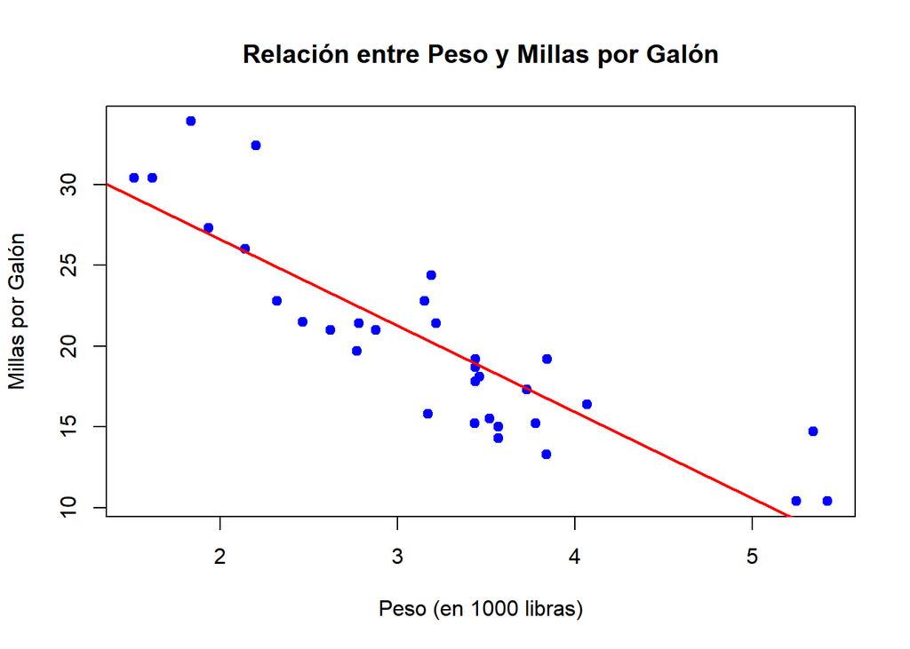

```r
# Crear el gráfico de dispersión entre 'wt' y 'mpg'
plot(mtcars$wt, mtcars$mpg,
     main = "Relación entre Peso y Millas por Galón",
     xlab = "Peso (en 1000 libras)",
     ylab = "Millas por Galón",
     pch = 19, col = "blue")

# Añadir la línea de regresión al gráfico
abline(modelo_simple, col = "red", lwd = 2)
```

En el gráfico, los puntos azules representan los datos reales, y la línea roja muestra la relación lineal ajustada por el modelo.

## 3. Regresión Lineal Múltiple

### 3.1 Explicación

La **regresión lineal múltiple** permite incluir más de una variable independiente para predecir la variable dependiente. El modelo tiene la siguiente forma:

$$Y = \beta_0 + \beta_1 X_1 + \beta_2 X_2
+ \ldots + \beta_n X_n + \epsilon$$

### 3.2 Ejemplo: Predecir `mpg` usando `wt` (peso) y `hp` (caballos de fuerza) en `mtcars`

#### 1. Ajustar el modelo de regresión múltiple

```r
# Ajustar el modelo de regresión lineal múltiple
modelo_multiple <- lm(mpg ~ wt + hp, data = mtcars)

# Mostrar el resumen del modelo
summary(modelo_multiple)
```

```
##
## Call:
## lm(formula = mpg ~ wt + hp, data = mtcars)
##
## Residuals:
##    Min     1Q Median     3Q    Max
## -3.941 -1.600 -0.182  1.050  5.854
##
## Coefficients:
##             Estimate Std. Error t value Pr(>|t|)
## (Intercept) 37.22727    1.59879  23.285  < 2e-16 ***
## wt          -3.87783    0.63273  -6.129 1.12e-06 ***
## hp          -0.03177    0.00903  -3.519  0.00145 **
## ---
## Signif. codes:  0 '***' 0.001 '**' 0.01 '*' 0.05 '.' 0.1 ' ' 1
##
## Residual standard error: 2.593 on 29 degrees of freedom
## Multiple R-squared:  0.8268, Adjusted R-squared:  0.8148
## F-statistic: 69.21 on 2 and 29 DF,  p-value: 9.109e-12
```

### 3.3 Interpretación de los resultados

- **Intercepto ($\beta_0 = 37.23$)**: Este es el valor estimado de `mpg` cuando tanto el peso como los caballos de fuerza son 0. Aunque teóricamente interesante, no tiene sentido práctico en este contexto.
- **$\beta_1 = -3.88$**: Esto significa que por cada 1000 libras adicionales de peso, `mpg` disminuye en 3.88 millas por galón, manteniendo los caballos de fuerza constantes.
- **$\beta_2 = -0.03177$**: Esto indica que por cada unidad adicional de caballos de fuerza (`hp`), `mpg` disminuye en 0.03177 millas por galón, manteniendo constante el peso.
- **p-value**: Tanto `wt` como `hp` tienen valores p muy bajos, lo que indica que ambos predictores tienen un impacto significativo en `mpg`.
- **R-cuadrado ajustado (0.8148)**: El modelo explica aproximadamente el 81.48% de la variabilidad en `mpg`, lo que sugiere un ajuste sólido.

## 4. Diagnósticos del Modelo

Es importante verificar que el modelo cumple con los supuestos de la regresión lineal.

### 4.1 Gráfico de Residuos

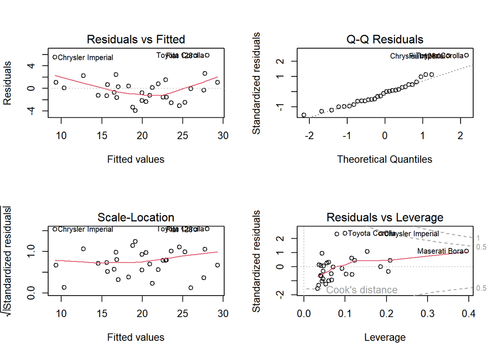

```r
# Gráfico de residuos
par(mfrow = c(2, 2))
plot(modelo_multiple)
```

#### 4.2 Interpretación de los gráficos:

1. **Residuals vs Fitted**: Los residuos deben estar distribuidos aleatoriamente. Si hay patrones, podría haber un problema de linealidad.
2. **Normal Q-Q**: Verifica la normalidad de los residuos. Si los puntos siguen una línea recta, es probable que los residuos sean normales.
3. **Scale-Location**: Evalúa la homocedasticidad (igual varianza de los residuos). Si los puntos están distribuidos de manera uniforme, entonces este supuesto se cumple.
4. **Residuals vs Leverage**: Identifica puntos que podrían estar influyendo demasiado en el modelo. Si hay puntos fuera de la región de confianza, pueden ser influyentes.

## 5. Ejercicios Prácticos

### **Ejercicio 1**: Regresión lineal simple

Usa el conjunto de datos `iris` para ajustar un modelo de regresión lineal simple que prediga la longitud del sépalo (`Sepal.Length`) a partir de la longitud del pétalo (`Petal.Length`).

```r
# Ajustar el modelo de regresión lineal simple
modelo_iris_simple <- lm(Sepal.Length ~ Petal.Length, data = iris)

# Mostrar el resumen del modelo
summary(modelo_iris_simple)
```

```
##
## Call:
## lm(formula = Sepal.Length ~ Petal.Length, data = iris)
##
## Residuals:
##      Min       1Q   Median       3Q      Max
## -1.24675 -0.29657 -0.01515  0.27676  1.00269
##
## Coefficients:
##              Estimate Std. Error t value Pr(>|t|)
## (Intercept)   4.30660    0.07839   54.94   <2e-16 ***
## Petal.Length  0.40892    0.01889   21.65   <2e-16 ***
## ---
## Signif. codes:  0 '***' 0.001 '**' 0.01 '*' 0.05 '.' 0.1 ' ' 1
##
## Residual standard error: 0.4071 on 148 degrees of freedom
## Multiple R-squared:   0.76,  Adjusted R-squared:  0.7583
## F-statistic: 468.6 on 1 and 148 DF,  p-value: < 2.2e-16
```

**Interpretación**: - La pendiente indica cómo cambia la longitud del sépalo por cada unidad de cambio en la longitud del pétalo. - El intercepto representa el valor esperado de la longitud del sépalo cuando la longitud del pétalo es 0.

### **Ejercicio 2**: Regresión lineal múltiple

Usa el conjunto de datos `mtcars` para ajustar un modelo de regresión lineal múltiple que prediga `mpg` usando `wt`, `hp`, y `qsec` como variables independientes.

```r
# Ajustar el modelo de regresión lineal múltiple
modelo_iris_multiple <- lm(mpg ~ wt + hp + qsec, data = mtcars)

# Mostrar el resumen del modelo
summary(modelo_iris_multiple)
```

```
##
## Call:
## lm(formula = mpg ~ wt + hp + qsec, data = mtcars)
##
## Residuals:
##     Min      1Q  Median      3Q     Max
## -3.8591 -1.6418 -0.4636  1.1940  5.6092
##
## Coefficients:
##             Estimate Std. Error t value Pr(>|t|)
## (Intercept) 27.61053    8.41993   3.279  0.00278 **
## wt          -4.35880    0.75270  -5.791 3.22e-06 ***
## hp          -0.01782    0.01498  -1.190  0.24418
## qsec         0.51083    0.43922   1.163  0.25463
## ---
## Signif. codes:  0 '***' 0.001 '**' 0.01 '*' 0.05 '.' 0.1 ' ' 1
##
## Residual standard error: 2.578 on 28 degrees of freedom
## Multiple R-squared:  0.8348, Adjusted R-squared:  0.8171
## F-statistic: 47.15 on 3 and 28 DF,  p-value: 4.506e-11
```

**Interpretación**: - Este modelo incluye tres predictores. Analiza el impacto de cada uno controlando por los demás. - El R-cuadrado ajustado te indicará cuánta variabilidad del `mpg` es explicada por el peso, los caballos de fuerza, y el tiempo en el cuarto de milla (`qsec`).